# Text Mining Rush Lyrics

Section 4: Topic Models

Michael Foley

2021-09-28

> Section 4 of my [Battle of the Bands](https://mpfoley73.github.io/battle-of-the-bands/) text mining project compares recurring topics in songs by the writers from Queen, Rush, and AC/DC. Topic models identify dominant themes in text and are useful tools for summarizing large corposes.

## Background

Topic modeling searches for patterns of co-occurring words in a corpus of documents. Most topic models represent documents as the output of a probabilistic data-generating mechanism. The model optimizes the distribution parameters according to some criteria. The data generating mechanism is a pair of probability distributions.

The first probability distribution defines topics as weighted probabilities of terms from the vocabulary vector. The second probability distribution defines documents as weighted probabilities of topics. You might interpret the topic weights as *the probability that document x is about topic y*, or as *the degree of the association between document x and topic y*, or as *how much this topic y contributed to document x*.

STM differs from other topic models in that you can fit the model with controlling variables so that a) the first probability distribution (sometimes called the beta matrix) is a function of the controlling variables (a *topical content* model) and/or b) the second probability distribution (sometimes called the gamma matrix) is a function of the controlling variables (a *topical prevalence* model). If you think *how* a topic is discussed depends on the metadata features, control for them in a topical content model. E.g., middle-school children will discuss a topic differently form doctoral candidates. If you think *what* topics are expressed depends on the metadata features, control for them in a topical prevalence model. E.g., a survey with and open text comment accompanying a Likert rating will probably focus on different topics for each rating level.

That is my approach here. I assume there is overlap among the song writers, but that some topics are more strongly associated with some writers than others. I wonder if I can use topic models to identify similar songs.

My `lyrics` data frame consists of 466 songs and 16 columns. After the `lyrics` column, the remaining 8 columns are features engineered in the text complexity section.

```r
glimpse(lyrics)
```

```
## Rows: 466
## Columns: 16
## $ song_id            <int> 118582, 308581, 308216, 307643, 307531, 73849, 3075~
## $ band               <chr> "AC/DC", "AC/DC", "AC/DC", "AC/DC", "AC/DC", "AC/DC~
## $ album              <chr> "Dirty Deeds Done Dirt Cheap", "Stiff Upper Lip", "~
## $ song               <chr> "Ain't No Fun (Waiting 'Round to Be a Millionaire)"~
## $ writer             <fct> AC/DC, AC/DC, AC/DC, AC/DC, AC/DC, AC/DC, AC/DC, AC~
## $ released           <int> 1976, 2000, 2008, 1990, 1975, 1980, 1985, 1977, 198~
## $ song_url           <chr> "https://genius.com/Ac-dc-aint-no-fun-waiting-round~
## $ lyrics             <chr> "The following is a true story Only the names have ~
## $ n_lines            <int> 78, 49, 37, 88, 42, 55, 36, 47, 40, 39, 47, 42, 46,~
## $ n_words            <int> 509, 218, 196, 326, 239, 262, 223, 219, 187, 168, 1~
## $ words_per_line     <dbl> 6.697368, 4.448980, 5.297297, 4.724638, 5.690476, 5~
## $ syllables_per_word <dbl> 1.176817, 1.036697, 1.260204, 1.128834, 1.150628, 1~
## $ flesch             <dbl> 100.47843, 114.61470, 94.84498, 106.54011, 103.7160~
## $ flesch_kincaid     <dbl> 0.90841769, -1.62187044, 1.34635411, -0.42714591, 0~
## $ dale_chall         <dbl> 42.02125, 56.13663, 53.55915, 58.40871, 57.68863, 5~
## $ ttr                <dbl> 0.3339921, 0.3240741, 0.4081633, 0.1907692, 0.27196~
```

## N-Grams

A good first approach to analyzing lyrical content is to construct unigram and bigram counts. The **tidytext** provides an easy framework for tokenizing text into unigrams, pulling out connector words and other common “stop” words, and then taking summary statistics (usually just counts). Tidytext tokenizes into bigrams too, but bigrams are less insightful if one of the words is a stop word. [Josh Vanderleest](https://www.linkedin.com/in/josh-vanderleest-6674a87b) showed me a cool trick: tokenize into unigrams, remove stop words, reassemble into a stop-free document, then tokenize into bigrams.

```r
lyrics_tidy <- lyrics %>%

  # remove special chars
  mutate(lyrics_tidy = str_remove_all(lyrics, "[[:punct:]]")) %>%

  # create unigrams
  unnest_tokens(output = "word", input = lyrics_tidy) %>%

  # no misspellings here, so I'm skipping this step
  # left_join(
  #   fuzzyjoin::misspellings %>% distinct(misspelling, .keep_all = TRUE),
  #   by = c("word" = "misspelling")
  # ) %>%
  # mutate(word = coalesce(correct, word)) %>%
  # select(-correct) %>%

  # lemmatize words
  mutate(word = textstem::lemmatize_words(word, dictionary = lexicon::hash_lemmas)) %>%

  # remove stop words
  anti_join(stop_words, by = "word") %>%

  # reconstruct the lyrics
  nest(word_list = word) %>%
  mutate(lyrics_tidy = map_chr(word_list, ~ unlist(.) %>% paste(., collapse = " "))) %>%
  select(-word_list)
```

`lyrics_tidy` has a new column, `lyrics_tidy` that has stop words removed, and words lemmatized. Here is what Freddie Mercury’s Bohemian Rhapsody looks like before and after this processing.

```r
lyrics_tidy %>%
  filter(song == "Bohemian Rhapsody") %>%
  pivot_longer(cols = c(lyrics, lyrics_tidy)) %>%
  select(song, value) %>%
  head() %>%
  flextable::as_grouped_data("song") %>%
  flextable::flextable() %>%
  flextable::autofit() %>%
  flextable::theme_vanilla() %>%
  flextable::bg(i = ~ !is.na(song), bg = "gray80") %>%
  flextable::border(i = c(2), border.bottom = officer::fp_border()) %>%
  flextable::border(j = 2, border.right = officer::fp_border())
```

| song | value |
| --- | --- |
| Bohemian Rhapsody |  |
|  | Is this the real life? Is this just fantasy? Caught in a landslide, no escape from reality Open your eyes, look up to the skies and see I'm just a poor boy, I need no sympathy Because I'm easy come, e… |
|  | real life fantasy catch landslide escape reality eye sky im poor boy sympathy im easy easy low wind blow doesnt matter mama kill gun head pull trigger hes dead mama life begin ive throw mama ooh didnt… |

### Unigrams

Unnesting tokens into unigrams with counts gives the following “top 5” words for each writer.

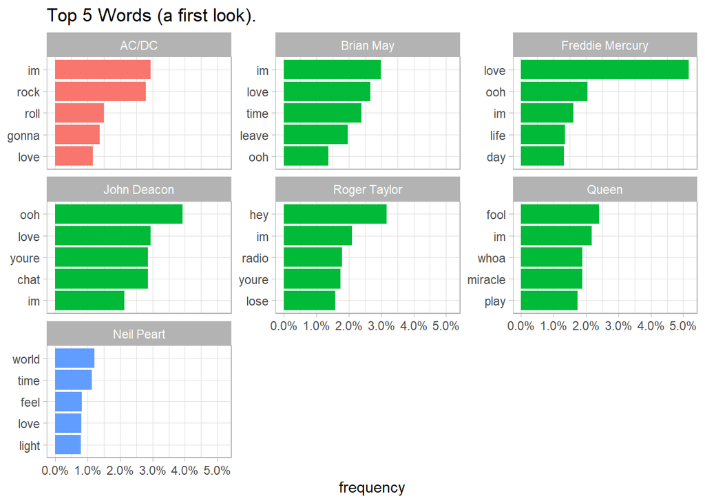

```r
tidy_top5_plot <- function(x, title_text) {
  x %>%
    group_by(band, writer) %>%
    count(token) %>%
    mutate(token_pct = n / sum(n)) %>%
    slice_max(order_by = token_pct, n = 5, with_ties = FALSE) %>%
    mutate(token = reorder_within(token, token_pct, writer)) %>%
    ggplot(aes(x = token, y = token_pct, fill = band)) +
    geom_col() +
    scale_color_manual(values = band_palette) +
    scale_x_reordered() +
    scale_y_continuous(labels = scales::percent_format(accuracey = 1)) +
    facet_wrap(facets = vars(writer), scales = "free_y") +
    coord_flip() +
    theme_light() +
    theme(legend.position = "none") +
    labs(x = NULL, y = "frequency", title = title_text)
}

# This is a first attempt at a word count. A better one comes later.
lyrics_word <- lyrics_tidy %>%
  unnest_tokens(output = "token", input = lyrics_tidy, token = "words")

lyrics_word %>% tidy_top5_plot("Top 5 Words (a first look).")
```

“I’m” is a top-5 word for every writer except Neil Peart. Peart rarely wrote explicity about himself. There are some gibberish words like “ooh” that don’t add much insight. I’ll remove them and try again.

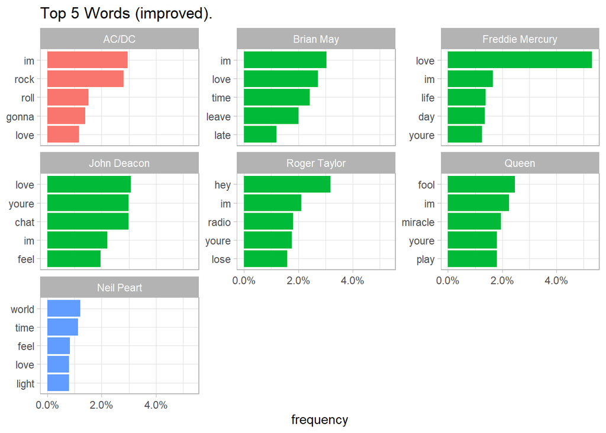

```r
custom_stop_words <- data.frame(token = c("ooh", "whoa"))

# This is the final word count
lyrics_word_2 <- lyrics_word %>%
  anti_join(custom_stop_words, by = "token")

lyrics_word_2 %>% tidy_top5_plot("Top 5 Words (improved).")
```

“Love” is another prevalent word, appearing in the top-5 for everyone except Roger Taylor and Queen. AC/DC was distinctive with reference to rock ’n roll. Peart had a relatively low word frequency for his top-5, suggesting he had a wider range of words and themes in songs.

### Bigrams

Bigrams are easier to interpret, but they also can mask ideas with variation in phrasing. Here are the bigrams pulled from the distilled `lyrics_tidy` column.

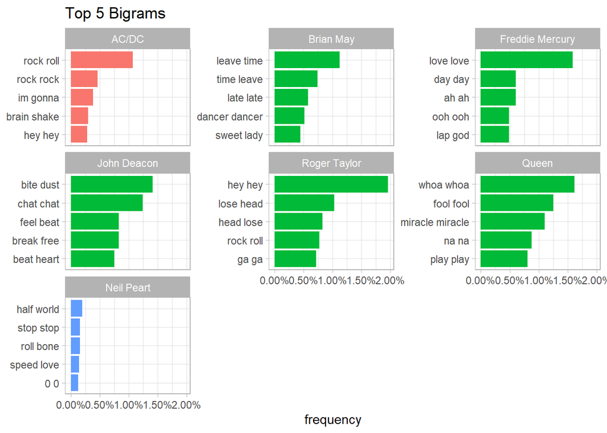

```r
lyrics_bigram <- lyrics_tidy %>%
  unnest_tokens(output = "token", input = lyrics_tidy, token = "ngrams", n = 2) %>%
  filter(!is.na(token))

lyrics_bigram %>% tidy_top5_plot("Top 5 Bigrams")
```

AC/DC is all about rock ’n roll. Brian May’s songs [It’s Late](https://genius.com/Queen-its-late-lyrics), [Dancer](https://genius.com/Queen-dancer-lyrics), and [Sweet Lady](https://genius.com/Queen-sweet-lady-lyrics) are evident in his list. The same is true for Deacon, Queen, and Neil Peart. Songs with repeating phrases appear in the bigrams - not very interesting.

## Modeling

I will fit a structural topic model (STM) following the procedure from the [stm vignette](https://www.structuraltopicmodel.com/).]

### Process and Prepare

Process the data first. Some of this is overlap with the processing I’ve just completed.

```r
processed <- stm::textProcessor(
  lyrics_tidy$lyrics_tidy,
  metadata = lyrics_tidy,
  stem = FALSE,
  customstopwords = custom_stop_words$token
)
```

```
## Building corpus...
## Converting to Lower Case...
## Removing punctuation...
## Removing stopwords...
## Remove Custom Stopwords...
## Removing numbers...
## Creating Output...
```

`textProcessor()` produces a list object with three main components:

- a `vocab` named vocabulary vector. The vector has 4,844 words.
- a `documents` list of matrices, one per document. Each matrix has 2 rows of integers. The first row is indices from the vocabulary vector; the second is their associated word counts. This is a concise representation of a document term matrix. The processing step sometimes removes a few documents that are empty after removing chaff. However, I still have all 466 rows in my `documents` list.
- a `meta` metadata data frame. There is one row per document (466 rows) containing all the song features I’ve collected in prior sections.

Next, “prepare” the corpus by removing infrequently used words. You can leave all words in, but in improves performance to cull out words with such low frequencies that they are unlikely to contribute to topics. The following diagnostic plot helps.

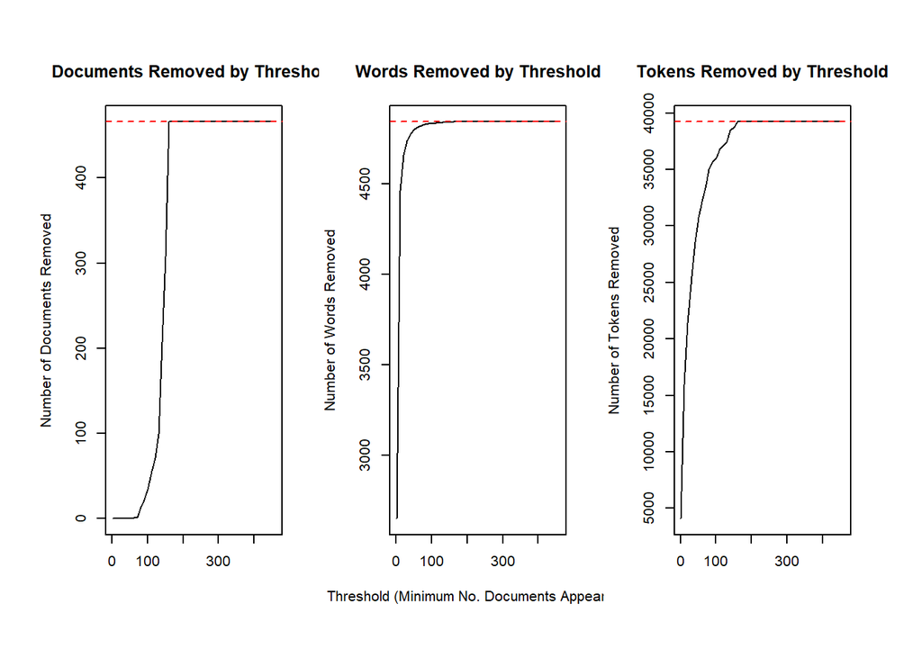

```r
stm::plotRemoved(
  processed$documents,
  lower.thresh = seq(1, length(processed$documents), by = 10)
)
```

If you remove words appearing in less than half the songs, all songs will be empty. 1% is a conservative threshold. Only words appearing in at least 1% of songs in the corpus will be included in a topic. `prepDocuments()` removes words with frequencies below the defined threshold, then updates the vocabulary, documents, and metadata.

```r
prepared <- stm::prepDocuments(
  processed$documents,
  processed$vocab,
  processed$meta,
  lower.thresh = length(processed$documents) * .01
)
```

[output not shown]

I didn’t lose any songs - I’m still at 466 songs. The vocabulary vector shrank from 4,844 words to 934 words. Here are the first 100, just to get a sense.

```r
prepared$vocab[1:100]
```

```
##   [1] "aah"       "ache"      "act"       "action"    "adventure" "afraid"
##   [7] "afternoon" "age"       "ago"       "agree"     "ahead"     "ahh"
##  [13] "aim"       "aint"      "air"       "alive"     "alright"   "ambition"
##  [19] "ancient"   "angel"     "anger"     "angry"     "animal"    "answer"
##  [25] "anymore"   "applause"  "arm"       "ass"       "attack"    "attention"
##  [31] "babe"      "baby"      "bad"       "balance"   "ball"      "band"
##  [37] "bang"      "bar"       "bare"      "battle"    "beam"      "bear"
##  [43] "beast"     "beat"      "beatin"    "beautiful" "beauty"    "bed"
##  [49] "bedroom"   "begin"     "belief"    "bell"      "belong"    "bend"
##  [55] "beneath"   "bill"      "bind"      "bird"      "bitch"     "bite"
##  [61] "bitter"    "black"     "blame"     "blast"     "bleed"     "blind"
##  [67] "blood"     "bloody"    "blow"      "blue"      "body"      "bodys"
##  [73] "boil"      "bomb"      "bone"      "book"      "booze"     "boss"
##  [79] "bottle"    "bottom"    "bout"      "bow"       "boy"       "brain"
##  [85] "brand"     "break"     "breath"    "breathe"   "bridge"    "bright"
##  [91] "bring"     "brother"   "build"     "bullet"    "burn"      "burnin"
##  [97] "business"  "busy"      "buy"       "cadillac"
```

### Fit the Model

The **stm** package allows you to either specify the number of topics (K) to identify, or it can choose an optimal number by setting parameter `K = 0`. I’ll let **stm** choose. The resulting probability distribution of topic words will then be a K x 934 matrix, sometimes called the *beta_matrix*. The probability distribution of song topics will be a 466 x K matrix, sometimes called the *gamma_matrix* (*theta* in the **stm** package).

I expect lyrics to be correlated with the writer, so I will fit a *prevalence* model with `writer` as a covariate.

```r
fit_prevalence <- stm::stm(
  documents = prepared$documents,
  vocab = prepared$vocab,
  K = 0,
  prevalence = ~ writer,
  data = prepared$meta,
  init.type = "Spectral",
  verbose = FALSE
)

summary(fit_prevalence)
```

```
## A topic model with 50 topics, 466 documents and a 934 word dictionary.
```

```
## Topic 1 Top Words:
##       Highest Prob: dream, miss, grow, feel, world, live, adventure
##       FREX: miss, adventure, grow, cage, mountain, dream, promise
##       Lift: adventure, reel, miss, cage, misty, relation, mountain
##       Score: adventure, miss, cage, grow, reel, mountain, draw
## Topic 2 Top Words:
##       Highest Prob: hes, night, knife, afraid, light, dark, run
##       FREX: hes, afraid, knife, evil, fairy, whos, hero
##       Lift: afraid, hes, fairy, crack, knife, noble, green
##       Score: afraid, hes, knife, evil, shadow, fear, fairy
## Topic 3 Top Words:
##       Highest Prob: day, word, son, father, time, beautiful, rain
##       FREX: son, father, word, day, beautiful, agree, sad
##       Lift: agree, father, son, beautiful, stormy, word, page
##       Score: agree, day, father, word, beautiful, son, page
## Topic 4 Top Words:
##       Highest Prob: bring, life, save, measure, love, worth, faith
##       FREX: measure, bring, save, faith, worth, belief, market
##       Lift: belief, measure, market, tick, faith, save, worth
##       Score: measure, belief, bring, save, worth, faith, tick
## Topic 5 Top Words:
##       Highest Prob: hot, blood, bad, street, play, eye, baby
##       FREX: blood, hot, street, disguise, bad, whos, tease
##       Lift: blood, hot, tease, disguise, bend, booze, lion
##       Score: blood, hot, disguise, bad, tease, bend, drop
## Topic 6 Top Words:
##       Highest Prob: baby, body, dancer, home, talk, gonna, aint
##       FREX: body, dancer, baby, home, dance, whats, talk
##       Lift: body, dancer, beatin, mmm, stir, baby, twist
##       Score: body, dancer, baby, talk, home, aint, dance
## Topic 7 Top Words:
##       Highest Prob: love, bomb, funny, bear, speed, hungry, day
##       FREX: bomb, love, funny, speed, hungry, bear, single
##       Lift: bomb, love, funny, hungry, speed, single, everythings
##       Score: love, bomb, funny, speed, hungry, bear, single
## Topic 8 Top Words:
##       Highest Prob: bone, hand, paper, stone, cut, business, head
##       FREX: bone, paper, stone, business, fist, hand, cut
##       Lift: bone, paper, fist, business, flesh, vision, stone
##       Score: bone, paper, business, fist, stone, vision, cut
```

[output cut: 195 more lines]

```
## Topic 48 Top Words:
##       Highest Prob: theyre, dirty, ball, cheap, weve, time, ive
##       FREX: theyre, dirty, cheap, ball, weve, wouldnt, trouble
##       Lift: theyre, dirty, cheap, wouldnt, ball, class, rat
##       Score: theyre, dirty, ball, cheap, wouldnt, weve, class
## Topic 49 Top Words:
##       Highest Prob: war, blow, time, run, wind, wheel, grow
##       FREX: war, shore, blow, middle, gently, tide, bow
##       Lift: war, west, gently, middle, brother, shore, tide
##       Score: war, shore, bow, middle, blow, west, wheel
## Topic 50 Top Words:
##       Highest Prob: shoot, love, warn, life, honey, sun, trip
##       FREX: shoot, warn, love, trip, honey, double, bleed
##       Lift: warn, shoot, trip, bleed, double, pump, jump
##       Score: warn, shoot, love, trip, bleed, double, honey
```

### Interpretation

- **Highest Probability** weights words by their overall frequency.
- **FREX** weights words by their overall frequency and how exclusive they are to the topic.
- **Lift** weights words by dividing by their frequency in other topics, therefore giving higher weight to words that appear less frequently in other topics.
- **Score** divides the log frequency of the word in the topic by the log frequency of the word in other topics.

Let’s look at Topic 2:

```r
stm::labelTopics(fit_prevalence, topics = 2)
```

```
## Topic 2 Top Words:
##       Highest Prob: hes, night, knife, afraid, light, dark, run
##       FREX: hes, afraid, knife, evil, fairy, whos, hero
##       Lift: afraid, hes, fairy, crack, knife, noble, green
##       Score: afraid, hes, knife, evil, shadow, fear, fairy
```

```r
topic_thoughts <- stm::findThoughts(
  fit_prevalence,
  n = 3,
  texts = processed$meta$lyrics,
  topics = 2,
  meta = processed$meta
)

processed$meta[pluck(topic_thoughts$index, 1), ] %>% select(writer, song)
```

```
##              writer                             song
## 96            AC/DC         Night of the Long Knives
## 354      Neil Peart                      Digital Man
## 260 Freddie Mercury The Fairy Feller's Master-Stroke
```